title: “”NYC weather impacts on flight delay 2013“” output: pdf_document author: Thuy Quach

```r
# Set up knitr
knitr::opts_chunk$set(fig.width=12, fig.height=8, fig.path='Figs/',
echo=FALSE, warning=FALSE, message=FALSE)
```

```
##
##  /var/folders/4g/g4gbmv3s773813tqb3cbhgrr0000gp/T//RtmpgBfXI7/downloaded_packages
```

#### Problem 1: Flight Delays

Flight delays are often linked to weather conditions. How does weather impact flights from NYC? Utilize both the `flights` and `weather` datasets from the `nycflights13` package to explore this question. Include at least two visualizations to aid in communicating what you find.

##### Dataset:

##### Summary of the dataset:

First let’s see the total of the flight data and weather data

```
## [1] 327346
```

```
## [1] 7568
```

Then let’s explore the variables and the data structure of the flight data

```
##       year          month             day           dep_time
##  Min.   :2013   Min.   : 1.000   Min.   : 1.00   Min.   :   1
##  1st Qu.:2013   1st Qu.: 4.000   1st Qu.: 8.00   1st Qu.: 907
##  Median :2013   Median : 7.000   Median :16.00   Median :1400
##  Mean   :2013   Mean   : 6.565   Mean   :15.74   Mean   :1349
##  3rd Qu.:2013   3rd Qu.:10.000   3rd Qu.:23.00   3rd Qu.:1744
##  Max.   :2013   Max.   :12.000   Max.   :31.00   Max.   :2400
##    dep_delay          arr_time      arr_delay          carrier
##  Min.   : -43.00   Min.   :   1   Min.   : -86.000   Length:327346
##  1st Qu.:  -5.00   1st Qu.:1104   1st Qu.: -17.000   Class :character
##  Median :  -2.00   Median :1535   Median :  -5.000   Mode  :character
##  Mean   :  12.56   Mean   :1502   Mean   :   6.895
##  3rd Qu.:  11.00   3rd Qu.:1940   3rd Qu.:  14.000
##  Max.   :1301.00   Max.   :2400   Max.   :1272.000
##    tailnum              flight        origin              dest
##  Length:327346      Min.   :   1   Length:327346      Length:327346
##  Class :character   1st Qu.: 544   Class :character   Class :character
##  Mode  :character   Median :1467   Mode  :character   Mode  :character
##                     Mean   :1943
##                     3rd Qu.:3412
##                     Max.   :8500
##     air_time        distance         hour           minute
##  Min.   : 20.0   Min.   :  80   Min.   : 0.00   Min.   : 0.00
##  1st Qu.: 82.0   1st Qu.: 509   1st Qu.: 9.00   1st Qu.:16.00
##  Median :129.0   Median : 888   Median :14.00   Median :31.00
##  Mean   :150.7   Mean   :1048   Mean   :13.17   Mean   :31.75
##  3rd Qu.:192.0   3rd Qu.:1389   3rd Qu.:17.00   3rd Qu.:49.00
##  Max.   :695.0   Max.   :4983   Max.   :24.00   Max.   :59.00
```

```
##  [1] "year"      "month"     "day"       "dep_time"  "dep_delay"
##  [6] "arr_time"  "arr_delay" "carrier"   "tailnum"   "flight"
## [11] "origin"    "dest"      "air_time"  "distance"  "hour"
## [16] "minute"
```

```
## Classes 'tbl_df', 'tbl' and 'data.frame':    327346 obs. of  16 variables:
##  $ year     : int  2013 2013 2013 2013 2013 2013 2013 2013 2013 2013 ...
##  $ month    : int  1 1 1 1 1 1 1 1 1 1 ...
##  $ day      : int  1 1 1 1 1 1 1 1 1 1 ...
##  $ dep_time : int  517 533 542 544 554 554 555 557 557 558 ...
##  $ dep_delay: num  2 4 2 -1 -6 -4 -5 -3 -3 -2 ...
##  $ arr_time : int  830 850 923 1004 812 740 913 709 838 753 ...
##  $ arr_delay: num  11 20 33 -18 -25 12 19 -14 -8 8 ...
##  $ carrier  : chr  "UA" "UA" "AA" "B6" ...
##  $ tailnum  : chr  "N14228" "N24211" "N619AA" "N804JB" ...
##  $ flight   : int  1545 1714 1141 725 461 1696 507 5708 79 301 ...
##  $ origin   : chr  "EWR" "LGA" "JFK" "JFK" ...
##  $ dest     : chr  "IAH" "IAH" "MIA" "BQN" ...
##  $ air_time : num  227 227 160 183 116 150 158 53 140 138 ...
##  $ distance : num  1400 1416 1089 1576 762 ...
##  $ hour     : num  5 5 5 5 5 5 5 5 5 5 ...
##  $ minute   : num  17 33 42 44 54 54 55 57 57 58 ...
##  - attr(*, "na.action")=Class 'omit'  Named int [1:9430] 472 478 616 644 726 734 755 839 840 841 ...
##   .. ..- attr(*, "names")= chr [1:9430] "472" "478" "616" "644" ...
```

There are 16 variables in flight data. There are year (2013), month( 1-12) and day (1-31) and other details about flight information.

Let’s explore weather data

```
##     origin               year          month             day
##  Length:7568        Min.   :2013   Min.   : 1.000   Min.   : 1.00
##  Class :character   1st Qu.:2013   1st Qu.: 4.000   1st Qu.: 8.00
##  Mode  :character   Median :2013   Median : 7.000   Median :16.00
##                     Mean   :2013   Mean   : 6.522   Mean   :15.74
##                     3rd Qu.:2013   3rd Qu.:10.000   3rd Qu.:23.00
##                     Max.   :2013   Max.   :12.000   Max.   :31.00
##       hour            temp             dewp           humid
##  Min.   : 0.00   Min.   : 10.94   Min.   :-9.04   Min.   : 13.95
##  1st Qu.: 5.00   1st Qu.: 39.02   1st Qu.:24.98   1st Qu.: 46.09
##  Median :11.00   Median : 55.04   Median :41.00   Median : 59.58
##  Mean   :11.38   Mean   : 55.20   Mean   :40.53   Mean   : 60.37
##  3rd Qu.:18.00   3rd Qu.: 71.06   3rd Qu.:57.02   3rd Qu.: 74.27
##  Max.   :23.00   Max.   :100.04   Max.   :75.92   Max.   :100.00
##     wind_dir       wind_speed         wind_gust            precip
##  Min.   :  0.0   Min.   :   0.000   Min.   :   0.000   Min.   :0.00000
##  1st Qu.:130.0   1st Qu.:   5.754   1st Qu.:   6.622   1st Qu.:0.00000
##  Median :230.0   Median :   9.206   Median :  10.594   Median :0.00000
##  Mean   :198.5   Mean   :   9.525   Mean   :  10.962   Mean   :0.00179
##  3rd Qu.:280.0   3rd Qu.:  12.659   3rd Qu.:  14.567   3rd Qu.:0.00000
##  Max.   :360.0   Max.   :1048.361   Max.   :1206.432   Max.   :0.38000
##     pressure          visib
##  Min.   : 983.9   Min.   : 0.120
##  1st Qu.:1012.7   1st Qu.:10.000
##  Median :1017.5   Median :10.000
##  Mean   :1017.8   Mean   : 9.559
##  3rd Qu.:1022.9   3rd Qu.:10.000
##  Max.   :1041.9   Max.   :10.000
```

```
##  [1] "origin"     "year"       "month"      "day"        "hour"
##  [6] "temp"       "dewp"       "humid"      "wind_dir"   "wind_speed"
## [11] "wind_gust"  "precip"     "pressure"   "visib"
```

[output not shown]

[output cut: 79 more lines]

[output not shown]

There are 14 variables in the weather dataset. There are year (2013), month( 1-12) and day (1-31) with other weather data such as temp, wind_speed, precip..ect.

###### Dep_delay vs weather

Since we are interested in how weather affects flight delay from NYC, here are the variables we should pay attention: dep_delay.

```
##    Min. 1st Qu.  Median    Mean 3rd Qu.    Max.
##  -43.00   -5.00   -2.00   12.56   11.00 1301.00
```

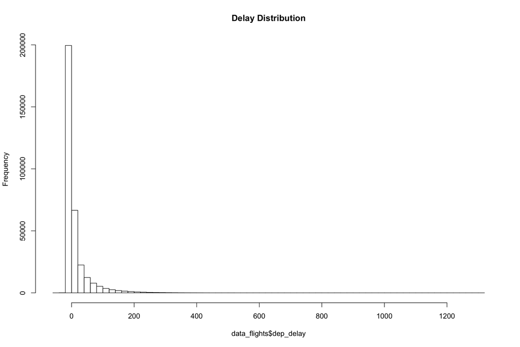

We see that there are a lot of outliers in the data, for example the maximum of dep_delay was 1301. Let’s see that data

```
## # A tibble: 1 × 16
##    year month   day dep_time dep_delay arr_time arr_delay carrier tailnum
##   <int> <int> <int>    <int>     <dbl>    <int>     <dbl>   <chr>   <chr>
## 1  2013     1     9      641      1301     1242      1272      HA  N384HA
## # ... with 7 more variables: flight <int>, origin <chr>, dest <chr>,
## #   air_time <dbl>, distance <dbl>, hour <dbl>, minute <dbl>
```

It was on Jan 9th, 2013 at 6:41 am. Let’s check the weather on that time.

```
## Source: local data frame [1 x 14]
## Groups: month, day, hour [1]
##
##   origin  year month   day  hour  temp  dewp humid wind_dir wind_speed
##    <chr> <dbl> <dbl> <int> <int> <dbl> <dbl> <dbl>    <dbl>      <dbl>
## 1    EWR  2013     1     9     6 33.98 28.94 81.57        0          0
## # ... with 4 more variables: wind_gust <dbl>, precip <dbl>,
## #   pressure <dbl>, visib <dbl>
```

Everything looks normal. It is very interesting. So, the delay may or may not becasue of weather.

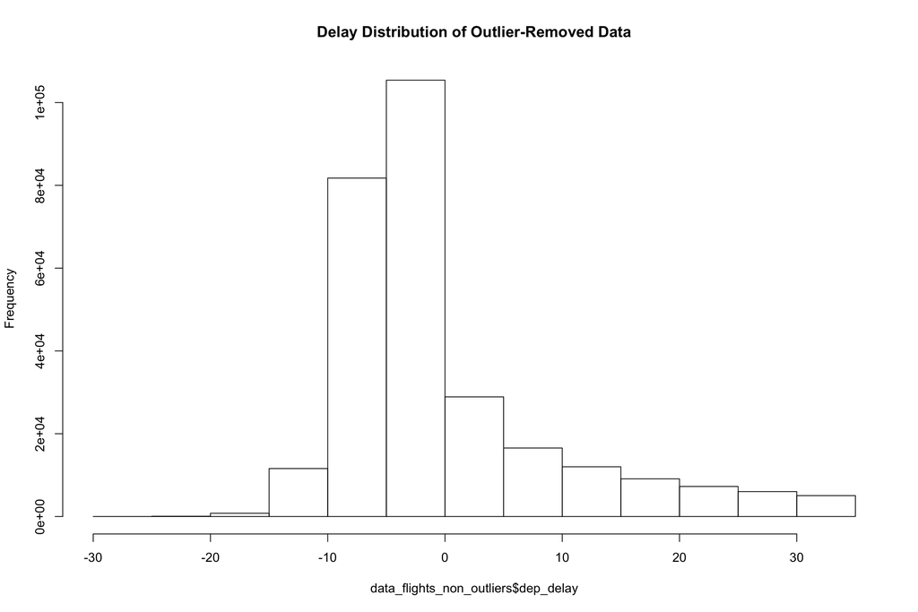

Keep the outliers for now before remove it. Next, we will try to group the weather data with the flight data

###### Group flight data into month, day, hour

###### Merge weather and flight data

Now the datas are joined. Why there are 327346 data in sub_flights but only 280619 in merged.data. Any missing date in data_weather? Yes, the total obs in weather data is only 7568 while total hours should be 8760 (365 days * 24 hour).

Let’s explore the correlation between dep_delay and other weather conditions. Keep in mind we have some extreme outliers that have no correlations at all with weather. The reason for the outliers could be engine failure, maintainance issues or logistics problems.

###### Correlation between delay and weather data

```
##                    [,1]
## temp        0.106899905
## dewp        0.086306032
## humid      -0.015289994
## wind_dir    0.004351011
## wind_speed  0.020288021
## wind_gust   0.020288021
## precip      0.039336705
## pressure   -0.103720779
## visib      -0.063001044
```

The correlation coefficients were very low, mostly around -0.1 to 0.1. To visualize it, I make the below graph.

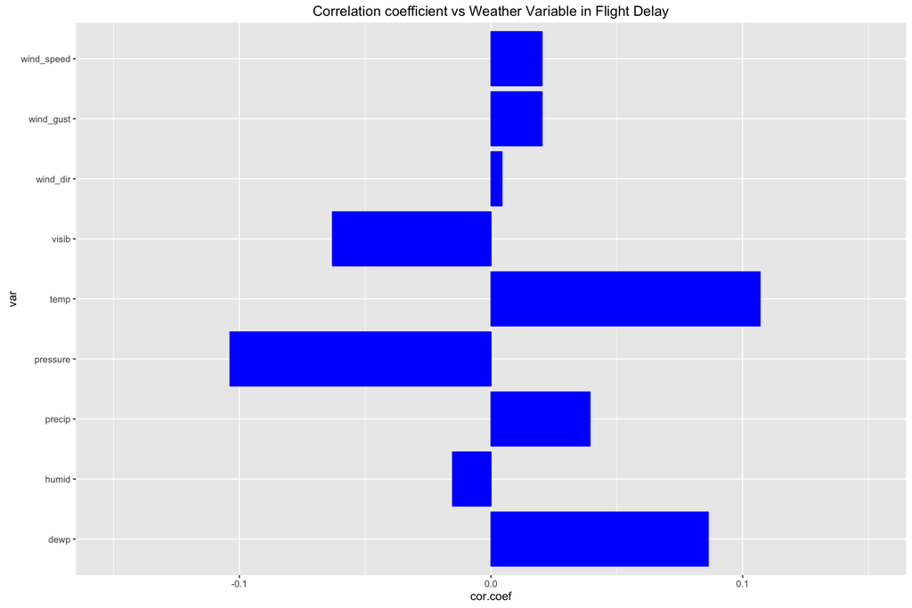

```
##                    [,1]
## temp        0.109449543
## dewp        0.113071183
## humid       0.034373190
## wind_dir   -0.020166253
## wind_speed  0.009732774
## wind_gust   0.009732774
## precip      0.031762338
## pressure   -0.112719062
## visib      -0.057217418
```

The correlations values of the subset are quite similar with the total data . Let’s try to see whether the delay is different between months.

###### Average departure delay by month:

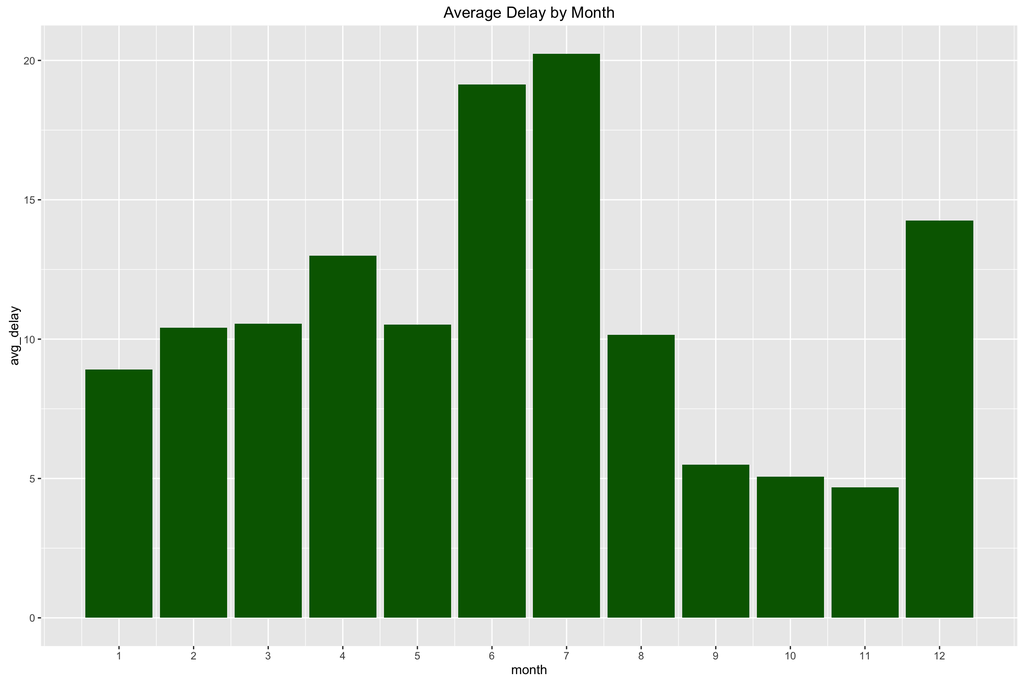

There is different of delay by month. Looks like the hottest month June and July have higher delay. December is also has higher delay which might be due to holidays. Let’s combine with temperature, dew point and precipitation data.

###### Average tempature vs departure delay by month:

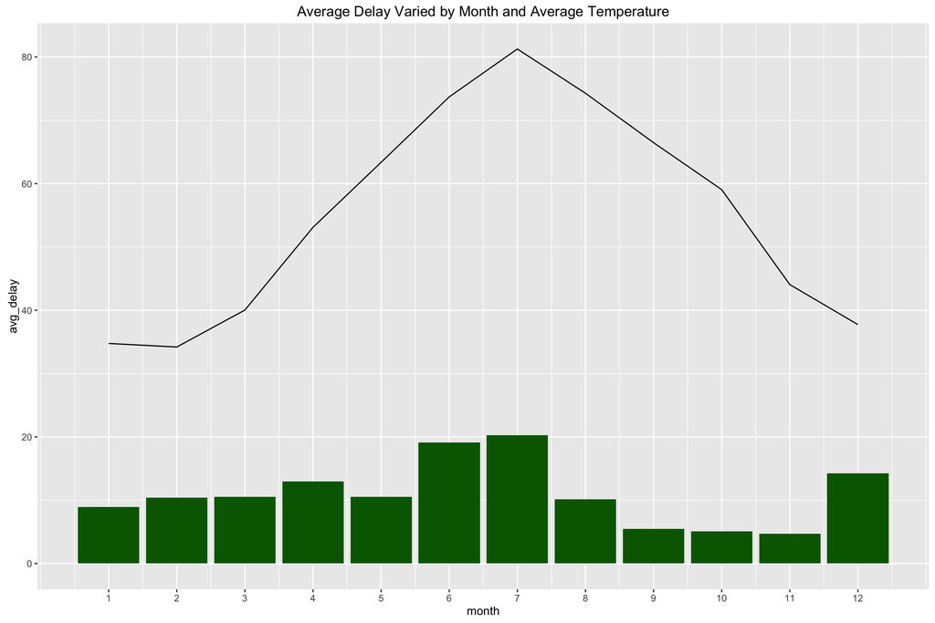

###### Average dew point vs departure delay by month:

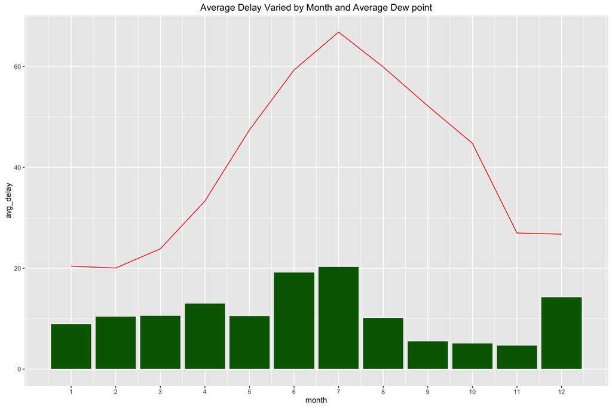

Dew point on June and July were also higher and correlated with higher departure delay.

##### Summary:

I then grouped the data by month and calculate the mean temperature and mean dew point. The visualizations of the data showed that on the hottest and most humidity month June and July, the delay were more likely to happen.